# The permutations package and representation theory

Robin K. S. Hankin

2023-02-22

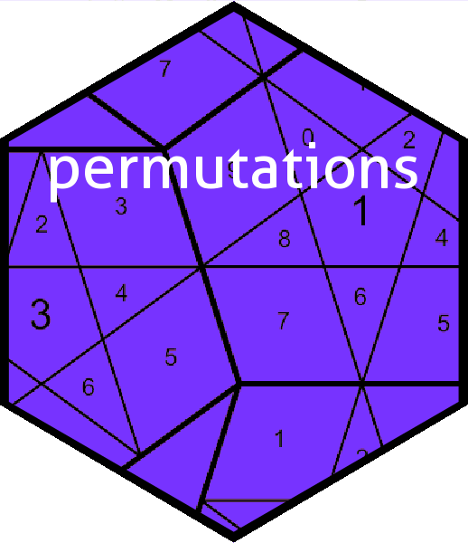

# Introduction

We will consider $S_9$, the symmetric group on 9 elements, and representations of its elements. First we will load the package and change the default print method:

```r
library("permutations")
options("print_word_as_cycle" = FALSE)
```

Now we will generate a couple of permutations, `a` and `b`:

```r
a <- as.word(char2cycle("(175296)(348)"))
b <- as.word(char2cycle("(27)(45)(89)"))
a
```

```
#>     {1} {2} {3} {4} {5} {6} {7} {8} {9}
#> [1] 7   9   4   8   2   1   5   3   6
```

```r
b
```

```
#>     {1} {2} {3} {4} {5} {6} {7} {8} {9}
#> [1] .   7   .   5   4   .   2   9   8
```

Now we will show a representation of $S_9$, using permutation matrices:

```r
M <- diag(9)
rownames(M) <- 1:9
colnames(M) <- 1:9
M
```

```
#>   1 2 3 4 5 6 7 8 9
#> 1 1 0 0 0 0 0 0 0 0
#> 2 0 1 0 0 0 0 0 0 0
#> 3 0 0 1 0 0 0 0 0 0
#> 4 0 0 0 1 0 0 0 0 0
#> 5 0 0 0 0 1 0 0 0 0
#> 6 0 0 0 0 0 1 0 0 0
#> 7 0 0 0 0 0 0 1 0 0
#> 8 0 0 0 0 0 0 0 1 0
#> 9 0 0 0 0 0 0 0 0 1
```

We will use the map $\phi\colon S_9\longrightarrow\operatorname{Aut}\left(\mathbb{R}^9\right)$ given by $\phi(a)=$ `M[a,]`. Then

```r
M[a,]
```

```
#>   1 2 3 4 5 6 7 8 9
#> 7 0 0 0 0 0 0 1 0 0
#> 9 0 0 0 0 0 0 0 0 1
#> 4 0 0 0 1 0 0 0 0 0
#> 8 0 0 0 0 0 0 0 1 0
#> 2 0 1 0 0 0 0 0 0 0
#> 1 1 0 0 0 0 0 0 0 0
#> 5 0 0 0 0 1 0 0 0 0
#> 3 0 0 1 0 0 0 0 0 0
#> 6 0 0 0 0 0 1 0 0 0
```

permutes the rows of $M$ with permutation `a`. Note how the row names are permuted as well as the elements of $M$. Verifying that $\phi$ is indeed a homomorphism—that is, $\phi(\iota)=I_9$ and $\phi(a)\phi(b)=\phi(a\circ b)$—is straightforward:

```r
all(M[as.word(id,9),] == diag(9))
```

```
#> [1] TRUE
```

```r
all(M[a*b,] == M[a,] %*% M[b,])
```

```
#> [1] TRUE
```

In the second line above, note that the left hand side of the equality is group composition, while the right hand side is matrix multiplication. We can further verify that $\phi\left(a^{-1}\right)=\phi(a)^{-1}$:

```r
all(M[inverse(a),] == solve(M[a,]))
```

```
#> [1] TRUE
```

again with group inversion on the left and matrix inversion on the right.

The map $\psi(a)=$ `M[,a]` is not a homomorphism:

```r
all(M[,a*b] == M[,a] %*% M[,b])
```

```
#> [1] FALSE
```

but we can “rescue” it by considering a group operation $\star$ defined by $a\star b=b\circ a$:

```r
all(M[,b*a] == M[,a] %*% M[,b])
```

```
#> [1] TRUE
```